# Notebook 07 – Solutions

## Getting Started

Before running this notebook, select “Session > Restart R and Clear Output” in the menu above to start a new R session. This will clear any old data sets and give us a blank slate to start with.

After starting a new session, run the following code chunk to load the libraries and data that we will be working with today.

I have set the options `include=FALSE` and `message=FALSE` to avoid cluttering the solutions with all the output from this code.

## Practice

### Movies data

For this notebook, we will be creating two datasets, reading them into R, and producing several data visualizations.

For the first task, we will create a dataset as a class describing a set of movies. Each student will be tasked with creating three rows of data. We will record the following items in the GoogleSheets file linked to on the class website:

- student number
- title
- date of release (year, month, and day)
- budget
- box-office numbers
- genre
- personal rating of the film, from 1-5 stars

Once you are finished, save the data set as a csv file, upload it to the “data” directory in RStudio, and read it into R in the following block of code:

```r
movies <- read_csv(file.path("data", "movie.csv"))
movies
```

```
## # A tibble: 55 × 12
##    number title  release_year release_month release_day budget box_office genre    rt
##     <dbl> <chr>         <dbl>         <dbl>       <dbl>  <dbl>      <dbl> <chr> <dbl>
##  1      1 Paras…         2019             5          30   15.5      259   Thri…    98
##  2      1 Ender…         2013            11           1  110        125   Sci-…    62
##  3      1 Shutt…         2010             2          19   80        295.  Thri…    68
##  4      2 Tekko…         2006            12          22    4.2       NA   Anim…    75
##  5      2 Ao no…         2003             3          15    3         58.3 Drama    NA
##  6      3 Lucy           2014             7          25   39        463.  Acti…    67
##  7      3 Soul           2020            10          11  150        119.  Anim…    95
##  8      3 The F…         2014             5          16   12        307.  Drama    81
##  9      4 The G…         2018            11          16   23        322.  Drama    77
## 10      4 Titan…         1997            12          19  200       2201   roma…    89
## # … with 45 more rows, and 3 more variables: imdb <dbl>, rating <dbl>, note <chr>
```

Then, produce a scatterplot below with the budget on the x-axis, box-office numbers on the y-axis, points colored by the year of release, and the size of the points corresponding to your personal rating. Use a text repel layer to label the movies by their title. Include axis labels and titles, along with units of measurement.

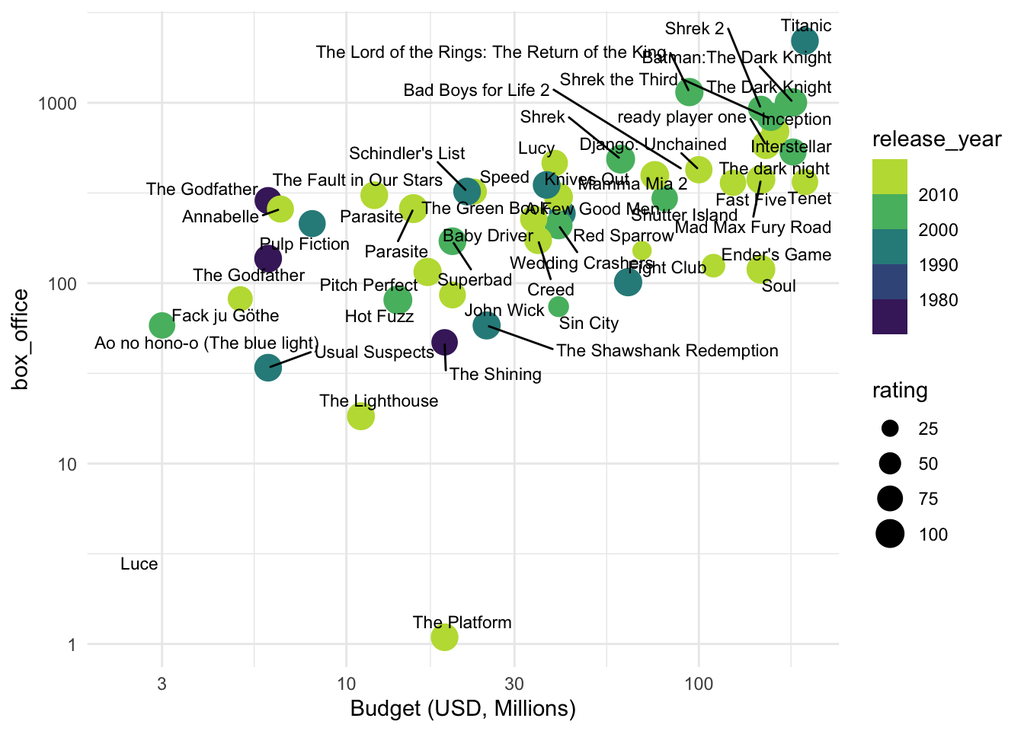

```r
movies %>%
  ggplot(aes(budget, box_office)) +
    geom_point(aes(color = release_year, size = rating)) +
    geom_text_repel(aes(label = title), size = 3) +
    labs(x = "Budget (USD, Millions)", x = "Box Office (USD, Millions)") +
    scale_x_log10() +
    scale_y_log10() +
    scale_color_viridis_b()
```

If you think it is needed, also include logarithmic scales for the x- and y-axes.

### Friends data

For the second data set, you are going to collect information about ten of your friends on your own. You can do this in any software you would like. At a minimum, record the following features:

- their name
- where you met them (make your own categories, such as “university”, “high school”, “camp”)
- the year you met the friend
- personal rating of the friend, from 1-5 stars

Once you are finished, save the data set as a csv file and read it into R in the following block of code:

```r
friends <- read_csv(file.path("data", "friends.csv"))
friends
```

```
## # A tibble: 10 × 4
##    name            where_met year_met rating
##    <chr>           <chr>        <dbl>  <dbl>
##  1 Roux            Louisiana     2021      6
##  2 Sarge           New Haven     2010      6
##  3 Joanna Wares    Richmond      2016      5
##  4 Heather Russell Richmond      2016      5
##  5 Kathy Rothert   Richmond      2016      5
##  6 Prateek Bhakta  Richmond      2016      5
##  7 Jon Park        Richmond      2018      5
##  8 Shweta Ware     Richmond      2020      5
##  9 Yucong Jiang    Richmond      2020      5
## 10 Paul Kvam       Richmond      2016      5
```

Then, produce a scatter plot below using any two variables that you find interesting as the x- and y-axes. Include a highlight layer showing a subset of your friends. These could be friends you met at a certain time in your life, highlighting your best friend(s) or something else that is interesting to you. Include axis labels and titles, along with units of measurement.

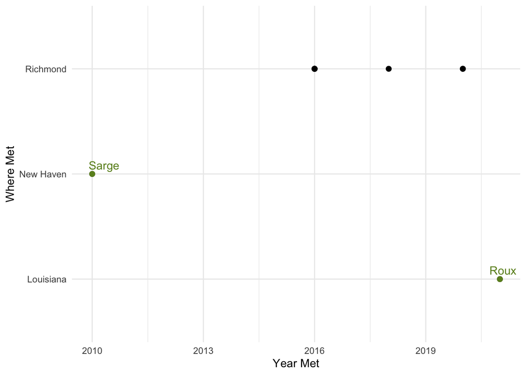

```r
best_friends <- friends %>%
  filter(rating > 5)

friends %>%
  ggplot(aes(year_met, where_met)) +
    geom_point(size = 2) +
    geom_point(data = best_friends, color = "olivedrab", size = 2) +
    geom_text_repel(aes(label = name), data = best_friends, color = "olivedrab") +
    labs(x = "Year Met", y = "Where Met")
```